# Importing packages

```python
        # Creating the wall states
        wall_states = self.random_generator.choice(range(1, self.nrow_maze * self.ncol_maze), size=maze_density, replace=False)

        # Getting the list of wall coordinates
        wall_coords = [self.get_state_coords(s) for s in wall_states]

        # Generating a starting state from the states that are NOT walls
        start_state = self.random_generator.choice(np.setdiff1d(self.S, wall_states))

        # Getting the starting coordinates
        start_coords = self.get_state_coords(start_state)

        # Generating a goal state from the states that are NOT walls and NOT the starting state
        goal_state = self.random_generator.choice(np.setdiff1d(np.setdiff1d(self.S, wall_states), start_state))

        # Getting the goal coordinates
        goal_coords = self.get_state_coords(goal_state)

        # Saving the wall coordinates, start coordinates, and goal coordinates
        self.wall_coords = wall_coords
        self.start_coords = [start_coords]
        self.goal_coords = [goal_coords]

        # Saving the indexes for the wall, start and goal states
        self.wall_states = wall_states
        self.start_state = start_state
        self.goal_state = goal_state

        # Initiating the reward dictionary
        self.init_reward_dict()

        # Initiating the agent
        self.init_agent()

    def get_state_index(self, row: int, col: int) -> int:
        """
        Returns the state index given the state coordinates.

        An inverse function of get_state_coords()
        """
        if (row < 0 or row >= self.nrow_maze or col < 0 or col >= self.ncol_maze):
            return -1
        else:
            return self.S[row][col]

    def get_state_coords(self, s) -> tuple:
        """
        Returns the state coordinates given the state index
        """
        s_index = np.where(self.S == s)
        if len(s_index[0]) == 0:
            return -1, -1

        return s_index[0][0], s_index[1][0]

    def get_action(
            self,
            ) -> int:
        """
        Returns a random action from the set of actions

        The actions are:
        0: up
        1: down
        2: left
        3: right
        """
        return self.random_generator.choice(self.actions)

    def argmax(self, q_values: np.array):
        """argmax with random tie-breaking
        Args:
            q_values (Numpy array): the array of action values
        Returns:
            action (int): an action with the highest value
        """
        top = float("-inf")
        ties = []

        for i in range(len(q_values)):
            if q_values[i] > top:
                top = q_values[i]
                ties = []

            if q_values[i] == top:
                ties.append(i)

        return self.random_generator.choice(ties)

    def get_greedy_action(self, state: int) -> int:
        """
        Returns the greedy action given the current state
        """
        # Getting the q values for the current state
        q_values = self.Q[state]

        # Getting the greedy action
        greedy_action = self.argmax(q_values)

        # Returning the greedy action
        return greedy_action

    def get_epsilon_greedy_action(self, state: int) -> int:
        """
        Returns an epsilon greedy action
        """
        if self.random_generator.random() < self.epsilon:
            return self.get_action()
        else:
            return self.get_greedy_action(state)

    # Logging of the agent paths
    def log_agent_move(self, state: int):
        """
        Logs the agent's move
        """
        if self.state_visit_paths.get(self.current_episode, None) is None:
            self.state_visit_paths[self.current_episode] = [state]
        else:
            self.state_visit_paths[self.current_episode].append(state)


    # Agent learning functions
    def update_Q_table_Q_Network(self, new_state: int):
        """
        Function that applies the RL update function
        """
        # Getting the next_state's reward
        reward = self.reward_dict[new_state]

        # Saving the current Q value
        current_Q = self.Q[self.past_state][self.past_action]

        # If the new state is the terminal state or the wall state, then the max_Q is 0
        max_Q = 0

        Y = reward

        # Else we get the max Q value for the new state
        if new_state != self.goal_state:

            with torch.no_grad():
              new_state_x, new_state_y = self.get_state_coords(new_state)

              new_state_Q_values = self.model(torch.from_numpy(np.array([new_state_x, new_state_y])).float())

            max_Q = torch.max(new_state_Q_values) #M

            Y = reward + (self.gamma * max_Q)

        # Updating inplace the Q value
        self.Q[self.past_state][self.past_action] = current_Q + self.alpha * (reward + self.gamma * max_Q - current_Q)

        Y = torch.Tensor([Y]).detach()
        X = torch.from_numpy(self.Q[self.past_state]).squeeze()[self.past_action]
        loss = self.loss_fn(X, Y) #P

        clear_output(wait=True)
        self.optimizer.zero_grad()
        loss = Variable(loss, requires_grad = True)
        loss.backward()


        self.optimizer.step()

        return loss

    def get_next_state(self, s: int, action: int) -> int:
        """
        Given the current state and the current action, returns the next state index
        """
        # Getting the state coordinates
        s_row, s_col = self.get_state_coords(s)

        # Setting the boolean indicating that we have reached the terminal state
        reached_terminal = False

        # Getting the next state
        next_state = -1
        if action == 0:
            next_state = self.get_state_index(s_row - 1, s_col)
        elif action == 1:
            next_state = self.get_state_index(s_row + 1, s_col)
        elif action == 2:
            next_state = self.get_state_index(s_row, s_col - 1)
        elif action == 3:
            next_state = self.get_state_index(s_row, s_col + 1)
```

```python
        # If next_state is a wall or the agent is out of bounds, we will stay in the same state
        if (next_state == -1) or (next_state in self.wall_states):
            return s, reached_terminal

        # Incrementing the number of times we have visited the next state
        self.increment_state_visit(next_state)

        # If next_state is the goal state, we will return to the starting state
        if next_state == self.goal_state:
            # Incrementing the number of times our agent has reached the goal state
            self.num_goal_reached += 1
            reached_terminal = True

        # Returning the next state
        return next_state, reached_terminal


    def init_agent(self):
        """
        We will set the past state and past action as the starting state and action
        """
        # Setting the previous state as the starting state
        self.past_state = self.start_state
        self.past_action = self.get_epsilon_greedy_action(self.past_state)
        self.num_goal_reached = 0

    def terminal_step(self, new_state: int):
        """
        Updates the agent one last time and resets the agent to the starting position
        """
        # Updating the Q table
        self.update_Q_table(new_state)

        # Resetting the agent
        self.past_state = self.start_state
        self.past_action = self.get_epsilon_greedy_action(self.past_state)

        # Incrementing the number of episodes
        self.current_episode += 1


    def terminal_step_Q_Network(self, new_state: int):
        """
        Updates the agent one last time and resets the agent to the starting position
        """
        # Updating the Q table
        loss = self.update_Q_table_Q_Network(new_state)

        print(loss)
        self.losses.append(loss.detach().numpy())

        # Resetting the agent
        self.past_state = self.start_state
        self.past_action = self.get_epsilon_greedy_action(self.past_state)

        # Incrementing the number of episodes
        self.current_episode += 1

    def move_agent(self):
        """
        The function that moves the agent to the next state
        """
        # Getting the next state
        next_state, reached_terminal = self.get_next_state(self.past_state, self.past_action)

        # Adding the next state to the path
        self.log_agent_move(next_state)

        # Updating the Q table
        if not reached_terminal:
            # Checking if the past_state is the same as the next_state; If that is true, it means our agent hit a wall
            # or went out of bounds
            if self.past_state != next_state:
                self.update_Q_table(next_state)

            # Setting the past_state as the next_state
            self.past_state = next_state

            # Getting the next action
            self.past_action = self.get_epsilon_greedy_action(self.past_state)
        else:
            self.terminal_step(next_state)


    def move_agent_Q_Network(self, num_episodes: int):
        """
        The function that moves the agent to the next state
        """
        # Getting the next state
        next_state, reached_terminal = self.get_next_state(self.past_state, self.past_action)

        # Adding the next state to the path
        self.log_agent_move(next_state)

        loss = 0

        # Updating the Q table
        if not reached_terminal:
            # Checking if the past_state is the same as the next_state; If that is true, it means our agent hit a wall
            # or went out of bounds
            if self.past_state != next_state:
                loss = self.update_Q_table_Q_Network(next_state)

            # Setting the past_state as the next_state
            self.past_state = next_state

            # Getting the next action
            self.past_action = self.get_epsilon_greedy_action(self.past_state)
        else:
            self.terminal_step_Q_Network(next_state)

            if self.epsilon > 0.1: #R
                self.epsilon -= (1/num_episodes)

    def train_episodes(self, num_episodes: int):
        """
        Function that trains the agent for one episode
        """
        # Calculating the episode number to end the training
        end_episode = self.current_episode + num_episodes - 1

        # Creating a dir to store the images
        os.makedirs(self.path_to_images_V, exist_ok=True)
        os.makedirs(self.path_to_images_Q, exist_ok=True)

        # If the directory for the first episode is not empty, we delete the files inside it
        if len(os.listdir(self.path_to_images_V)) > 0:
            for file in os.listdir(self.path_to_images_V):
                os.remove(os.path.join(self.path_to_images_V, file))

        if len(os.listdir(self.path_to_images_Q)) > 0:
            for file in os.listdir(self.path_to_images_Q):
                os.remove(os.path.join(self.path_to_images_Q, file))

        # Moving the agent until we reach the goal state
        while self.current_episode != end_episode:

            print(f"Episode {self.current_episode}")

            self.move_agent()

            plot_V_Table(
                S=self.S,
                Q=self.Q,
                goal_coords=self.goal_coords,
                wall_coords=self.wall_coords,
                start_coords=self.start_coords,
                title=f"V Table at Episode {self.current_episode}",
                filename=f"{self.path_to_images_V}/episode_{self.current_episode}.png"
                )

            plot_Q_Table(
                S=self.S,
                Q=self.Q,
                goal_coords=self.goal_coords,
                wall_coords=self.wall_coords,
                start_coords=self.start_coords,
                title=f"Q Table at Episode {self.current_episode}",
                filename=f"{self.path_to_images_Q}/episode_{self.current_episode}.png"
                )

    def train_episodes_Q_Network(self, num_episodes: int):
        """
        Function that trains the agent for one episode
        """
        # Calculating the episode number to end the training
        end_episode = self.current_episode + num_episodes - 1
```

```python
        # Creating a dir to store the images
        os.makedirs(self.path_to_images_V, exist_ok=True)
        os.makedirs(self.path_to_images_Q, exist_ok=True)

        # If the directory for the first episode is not empty, we delete the files inside it
        if len(os.listdir(self.path_to_images_V)) > 0:
            for file in os.listdir(self.path_to_images_V):
                os.remove(os.path.join(self.path_to_images_V, file))

        if len(os.listdir(self.path_to_images_Q)) > 0:
            for file in os.listdir(self.path_to_images_Q):
                os.remove(os.path.join(self.path_to_images_Q, file))




        # Moving the agent until we reach the goal state
        while self.current_episode != end_episode:

            print(f"Episode {self.current_episode}")

            print(self.reward_dict)


            self.move_agent_Q_Network(num_episodes)

            plot_V_Table(
                S=self.S,
                Q=self.Q,
                goal_coords=self.goal_coords,
                wall_coords=self.wall_coords,
                start_coords=self.start_coords,
                title=f"V Table at Episode {self.current_episode}",
                filename=f"{self.path_to_images_V}/episode_{self.current_episode}.png"
                )

            plot_Q_Table(
                S=self.S,
                Q=self.Q,
                goal_coords=self.goal_coords,
                wall_coords=self.wall_coords,
                start_coords=self.start_coords,
                title=f"Q Table at Episode {self.current_episode}",
                filename=f"{self.path_to_images_Q}/episode_{self.current_episode}.png"
                )



    def create_policy(self):
        """
        Creates a policy dictionary where the key is the state and the value is the action
        based on the Q table
        """
        # Creating the policy dictionary
        self.policy = {}

        # Looping through the states
        for state in range(self.S.size):
            # Getting the greedy action
            greedy_action = self.argmax(self.Q[state])

            # Adding the state and action to the policy dictionary
            self.policy[state] = greedy_action

    def create_optimal_policy_path(self):
        """
        Creates the path of the optimal policy, starting from the starting state
        """
        # Creating the policy path
        self.optimal_policy_path = [self.start_state]
        self.optimal_policy_path_coords = [self.get_state_coords(self.start_state)]

        # Getting the current state
        current_state = self.start_state

        # Looping through the states
        while current_state != self.goal_state:
            # Getting the next state
            next_state, _ = self.get_next_state(current_state, self.policy[current_state])

            # Adding the next state to the path
            self.optimal_policy_path.append(next_state)
            self.optimal_policy_path_coords.append(self.get_state_coords(next_state))

            # Setting the current state as the next state
            current_state = next_state
```

# Q Network Agent learning

First, let us create the agent object and initiate the maze environment for it.

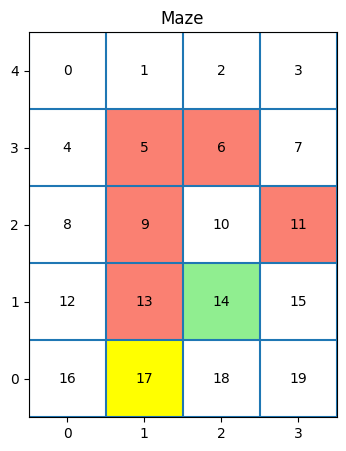

```python
agent = Agent(
    nrow_maze=5,
    ncol_maze=4,
    seed=0,
    rewards={'step': 0, 'goal': 10}
)

# Initiating the maze
agent.init_maze(maze_density=5)

# Ploting the maze
plot_matrix(agent.S, goal_coords=agent.goal_coords, hole_coords=agent.wall_coords, start_coords=agent.start_coords, title="Maze")
```

Display the initial Q table

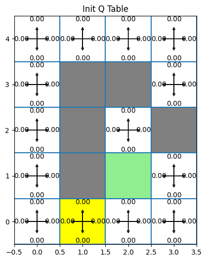

```python
plot_Q_Table(
    S=agent.S,
    Q=agent.Q,
    goal_coords=agent.goal_coords,
    wall_coords=agent.wall_coords,
    start_coords=agent.start_coords,
    title="Init Q Table"
    )
```

Display the initial V table

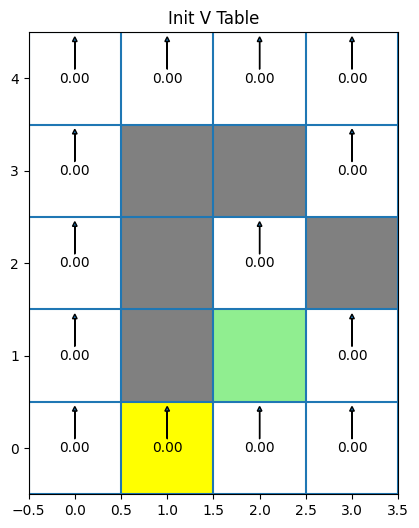

```python
plot_V_Table(
    S=agent.S,
    Q=agent.Q,
    goal_coords=agent.goal_coords,
    wall_coords=agent.wall_coords,
    start_coords=agent.start_coords,
    title="Init V Table"
    )
```

Train agent

```python
# Training the agent for 100 episodes
agent.train_episodes_Q_Network(num_episodes=100)
```

```
tensor(3.9695e-07, dtype=torch.float64, requires_grad=True)
```

MSE Loss over all episodes

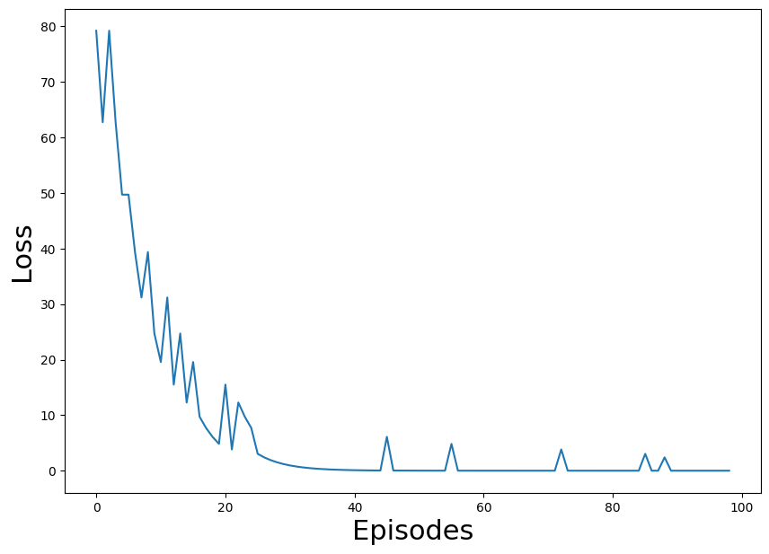

```python
plt.figure(figsize=(10,7))
plt.plot(agent.losses)
plt.xlabel("Episodes",fontsize=22)
plt.ylabel("Loss",fontsize=22)
plt.show()
```

Obtain the optimal policy after training

```python
# Creating the policy dictionary
agent.create_policy()

# Creating the optimal policy path
agent.create_optimal_policy_path()
```

Plot the optimal policy

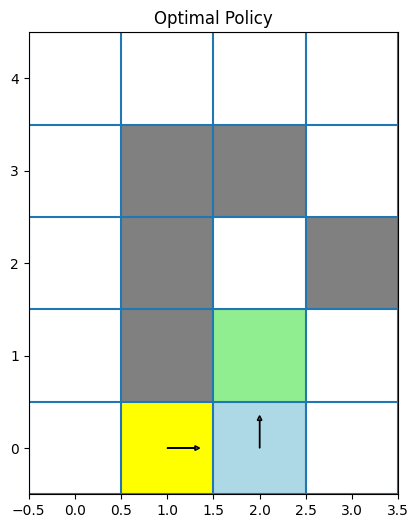

```python
plot_policy(
    S=agent.S,
    policy=agent.policy,
    optimal_policy_path=agent.optimal_policy_path_coords,
    goal_coords=agent.goal_coords,
    wall_coords=agent.wall_coords,
    start_coords=agent.start_coords,
    title="Optimal Policy"
    )
```

Plot the optimal Q table

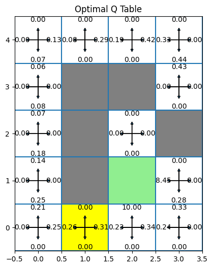

```python
plot_Q_Table(
    S=agent.S,
    Q=agent.Q,
    goal_coords=agent.goal_coords,
    wall_coords=agent.wall_coords,
    start_coords=agent.start_coords,
    title="Optimal Q Table"
    )
```

Plot the optimal V table

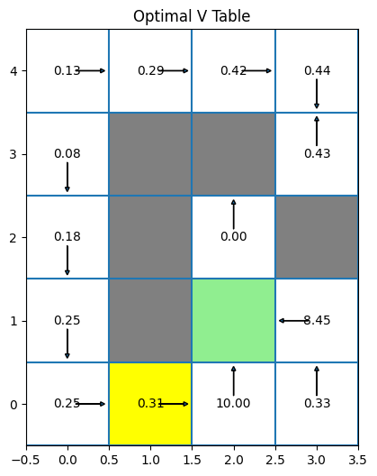

```python
plot_V_Table(
    S=agent.S,
    Q=agent.Q,
    goal_coords=agent.goal_coords,
    wall_coords=agent.wall_coords,
    start_coords=agent.start_coords,
    title="Optimal V Table"
    )
```

Plot the number of times each grid is visited over the training episodes

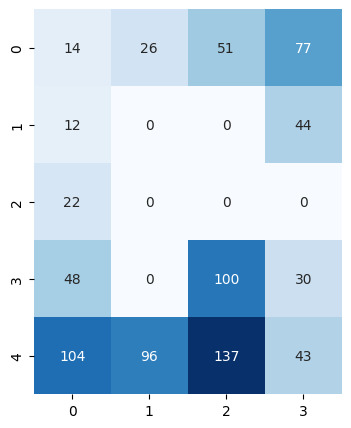

```python
plot_state_visits(agent.S, agent.state_visit_counter)
```

# Animating the agent exploration

Animate the agent's behavior during 1st episode

```python
# Extracting the first episode's path
first_episode_path = agent.state_visit_paths[0]

# Converting the state indexes to coords
first_episode_path_coords = [agent.get_state_coords(state) for state in first_episode_path]

# Defining the path to intermediate images
path_to_images = "q-learning-walking_paths"

# Defining the path to the first episode exploration
path_to_first_episode = "q-learning-walking_paths/episode_1"

# Creating a dir to store the images
os.makedirs(path_to_images, exist_ok=True)
os.makedirs(path_to_first_episode, exist_ok=True)

# If the directory for the first episode is not empty, we delete the files inside it
if len(os.listdir(path_to_first_episode)) > 0:
    for file in os.listdir(path_to_first_episode):
        os.remove(os.path.join(path_to_first_episode, file))

# Plotting the first episode's path
for i, state in enumerate(first_episode_path_coords):
    plot_matrix(
        agent.S,
        goal_coords=agent.goal_coords,
        hole_coords=agent.wall_coords,
        start_coords=agent.start_coords,
        highlight_coords=[state],
        title=f"Step {i}",
        filename=f"{path_to_first_episode}/state_{i}.png"
        )
```

Animate the agent's behavior during last episode

```python
# Extracting the last episode
last_episode_path = agent.state_visit_paths[list(agent.state_visit_paths.keys())[-1]]

# Converting the state indexes to coords
last_episode_path_coords = [agent.get_state_coords(state) for state in last_episode_path]

# Defining the path to the last episode exploration
path_to_last_episode = f"{path_to_images}/episode_last"

# Creating a dir to store the images
os.makedirs(path_to_last_episode, exist_ok=True)

# If the directory for the last episode is not empty, we delete the files inside it
if len(os.listdir(path_to_last_episode)) > 0:
    for file in os.listdir(path_to_last_episode):
        os.remove(os.path.join(path_to_last_episode, file))

# Plotting the last episode's path
for i, state in enumerate(last_episode_path_coords):
    plot_matrix(
        agent.S,
        goal_coords=agent.goal_coords,
        hole_coords=agent.wall_coords,
        start_coords=agent.start_coords,
        highlight_coords=[state],
        title=f"Step {i}",
        filename=f"{path_to_last_episode}/state_{i}.png"
        )
```

Generate the animations

```python
# Applying
create_gif(path_to_first_episode, f"{path_to_gifs}/first_episode.gif")
create_gif(path_to_last_episode, f"{path_to_gifs}/last_episode.gif")


create_gif(agent.path_to_images_V, f"{path_to_gifs_V}/V_Table_Progress.gif")
create_gif(agent.path_to_images_Q, f"{path_to_gifs_Q}/Q_Table_Progress.gif")
```

First episode agent movement animation:

[figure not shown]

Last episode agent movement animation:

[figure not shown]

Q Table progress animation:

[figure not shown]

V table progress animation:

[figure not shown]

# References

1. https://github.com/Eligijus112/rl-snake-game
2. Sutton, Richard S., and Andrew G. Barto. Reinforcement learning: An introduction. MIT press, 2018.